# ridge_and_lasso

Now we analyze the baseball dataset with regularization. Regularization is a strategy for penalizing the Beta coefficients, such that we tend to shrink coefficients as we increase the regularization parameter, lambda. We examine two kinds of regularization: ridge and lasso. Ridge regression includes an penalty for Beta coefficients equal to *lambda x sum(beta[i]^2)* for i = 1 …. p. Lasso regression is similar, but the penalty for Beta is *lambda x sum(beta[i])* for i = 1 …. p.

First, we reload the dataset and remove the missing values.

```r
library(ISLR)
fix(Hitters)
names(Hitters)
```

```
##  [1] "AtBat"     "Hits"      "HmRun"     "Runs"      "RBI"
##  [6] "Walks"     "Years"     "CAtBat"    "CHits"     "CHmRun"
## [11] "CRuns"     "CRBI"      "CWalks"    "League"    "Division"
## [16] "PutOuts"   "Assists"   "Errors"    "Salary"    "NewLeague"
```

```r
nrow(Hitters)
```

```
## [1] 322
```

```r
Hitters=na.omit(Hitters)
dim(Hitters)
```

```
## [1] 263  20
```

Set the X matrix and the y response vector.

```r
x=model.matrix(Salary~., Hitters)[,-1]
y=Hitters$Salary
```

Next, we use the glmnet() function to create our models. We use the grid sequence to evaluate a range of lambda values from 10^10 to 10^-2. The alpha parameter is set to 0 for ridge regression, or 1 for lasso regression.

```r
library(glmnet)
grid=10^seq(10,-2,length=100)
ridge.mod=glmnet(x,y,alpha=0,lambda=grid)
```

Associated with each value of lamda, there is a vector of Beta values. In this case, we have a matrix of 100 lambda values x 20 Beta values (19 Beta values for features and one for the intercept).

```r
dim(coef(ridge.mod))
```

```
## [1]  20 100
```

```r
ridge.mod$lambda[50]
```

```
## [1] 11497.57
```

```r
coef(ridge.mod)[,50]
```

```
##   (Intercept)         AtBat          Hits         HmRun          Runs
## 407.356050200   0.036957182   0.138180344   0.524629976   0.230701523
##           RBI         Walks         Years        CAtBat         CHits
##   0.239841459   0.289618741   1.107702929   0.003131815   0.011653637
##        CHmRun         CRuns          CRBI        CWalks       LeagueN
##   0.087545670   0.023379882   0.024138320   0.025015421   0.085028114
##     DivisionW       PutOuts       Assists        Errors    NewLeagueN
##  -6.215440973   0.016482577   0.002612988  -0.020502690   0.301433531
```

Above are the coefficients when lambda is equal to 11498. We can check below the coefficients when lambda is equal to 705:

```r
ridge.mod$lambda[60]
```

```
## [1] 705.4802
```

```r
coef(ridge.mod)[,60]
```

```
##  (Intercept)        AtBat         Hits        HmRun         Runs
##  54.32519950   0.11211115   0.65622409   1.17980910   0.93769713
##          RBI        Walks        Years       CAtBat        CHits
##   0.84718546   1.31987948   2.59640425   0.01083413   0.04674557
##       CHmRun        CRuns         CRBI       CWalks      LeagueN
##   0.33777318   0.09355528   0.09780402   0.07189612  13.68370191
##    DivisionW      PutOuts      Assists       Errors   NewLeagueN
## -54.65877750   0.11852289   0.01606037  -0.70358655   8.61181213
```

Note that with a smaller value of lambda, the coefficients tended to increase. We can compute the L2 norm for both of the above models for comparison as well:

```r
sqrt(sum(coef(ridge.mod)[-1,50]^2))
```

```
## [1] 6.360612
```

```r
sqrt(sum(coef(ridge.mod)[-1,60]^2))
```

```
## [1] 57.11001
```

Note the large increase in the L2 norm as we decreased lambda.

```r
1:nrow(x)
```

```
##   [1]   1   2   3   4   5   6   7   8   9  10  11  12  13  14  15  16  17
##  [18]  18  19  20  21  22  23  24  25  26  27  28  29  30  31  32  33  34
##  [35]  35  36  37  38  39  40  41  42  43  44  45  46  47  48  49  50  51
##  [52]  52  53  54  55  56  57  58  59  60  61  62  63  64  65  66  67  68
##  [69]  69  70  71  72  73  74  75  76  77  78  79  80  81  82  83  84  85
##  [86]  86  87  88  89  90  91  92  93  94  95  96  97  98  99 100 101 102
## [103] 103 104 105 106 107 108 109 110 111 112 113 114 115 116 117 118 119
## [120] 120 121 122 123 124 125 126 127 128 129 130 131 132 133 134 135 136
## [137] 137 138 139 140 141 142 143 144 145 146 147 148 149 150 151 152 153
## [154] 154 155 156 157 158 159 160 161 162 163 164 165 166 167 168 169 170
## [171] 171 172 173 174 175 176 177 178 179 180 181 182 183 184 185 186 187
## [188] 188 189 190 191 192 193 194 195 196 197 198 199 200 201 202 203 204
## [205] 205 206 207 208 209 210 211 212 213 214 215 216 217 218 219 220 221
## [222] 222 223 224 225 226 227 228 229 230 231 232 233 234 235 236 237 238
## [239] 239 240 241 242 243 244 245 246 247 248 249 250 251 252 253 254 255
## [256] 256 257 258 259 260 261 262 263
```

```r
nrow(x)/2
```

```
## [1] 131.5
```

Now we divide the data into test and train data sets:

```r
set.seed(1)
train=sample(1:nrow(x), nrow(x)/2)
test=(-train)
y.test=y[test]

ridge.mod = glmnet(x[train,], y[train], alpha=0, lambda=grid, thresh=1e-12)
ridge.pred = predict(ridge.mod, s=4, newx=x[test,])
mean((ridge.pred-y.test)^2)
```

```
## [1] 101036.8
```

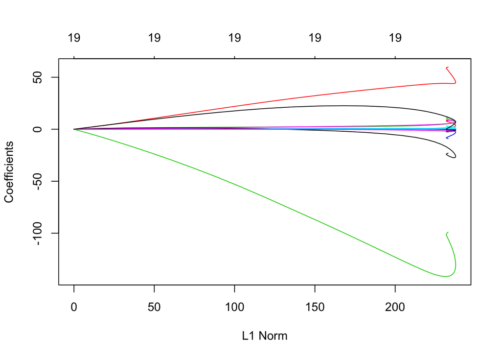

```r
plot(ridge.mod)
```

The above is the MSE using a lambda value of 4. However, if we had chosen lambda = a very large number, we have roughly a model that only has an intercept (all other Beta values forced to 0). In the case of intercept-only model, we have the MSE as:

```r
mean((mean(y[train])-y.test)^2)
```

```
## [1] 193253.1
```

If we choose lamda=1e10, we get a similar result:

```r
ridge.pred = predict(ridge.mod, s=1e10, newx=x[test,])
mean((ridge.pred-y.test)^2)
```

```
## [1] 193253.1
```

In general, it is better for us to use cross-validation to choose the tuning parameter lambda. We can do this using the built in function cv.glmnet(). By default, it performs a 10-fold cross-validation, but the folds can be set using the argument *folds*.

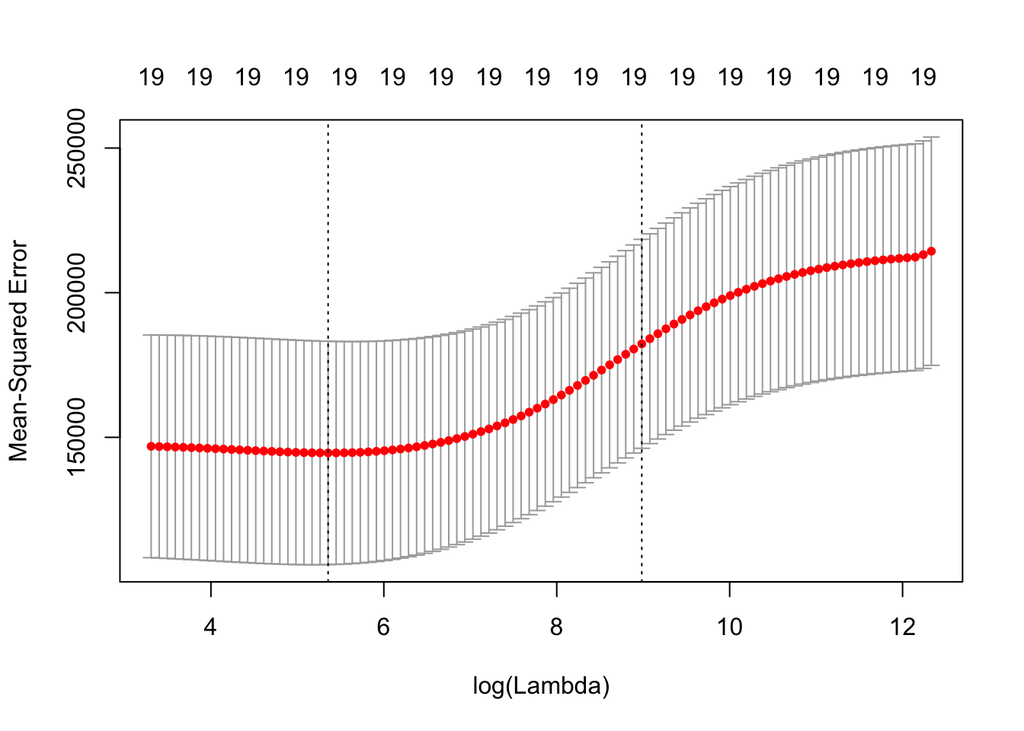

```r
set.seed(1)
cv.out=cv.glmnet(x[train,], y[train], alpha=0)
plot(cv.out)
```

```r
bestlambda=cv.out$lambda.min
bestlambda
```

```
## [1] 211.7416
```

We can find the *test MSE* associated with bestlambda=212.

```r
ridge.pred=predict(ridge.mod, s=bestlambda, newx=x[test,])
mean((ridge.pred-y.test)^2)
```

```
## [1] 96015.51
```

Finally, we refit on the full data set using lambda=bestlambda=212:

```r
final.model = glmnet(x,y,alpha=0)
predict(final.model, type="coefficients", s=bestlambda)
```

```
## 20 x 1 sparse Matrix of class "dgCMatrix"
##                        1
## (Intercept)   9.88487157
## AtBat         0.03143991
## Hits          1.00882875
## HmRun         0.13927624
## Runs          1.11320781
## RBI           0.87318990
## Walks         1.80410229
## Years         0.13074383
## CAtBat        0.01113978
## CHits         0.06489843
## CHmRun        0.45158546
## CRuns         0.12900049
## CRBI          0.13737712
## CWalks        0.02908572
## LeagueN      27.18227527
## DivisionW   -91.63411282
## PutOuts       0.19149252
## Assists       0.04254536
## Errors       -1.81244470
## NewLeagueN    7.21208394
```

Next, we check lasso regression:

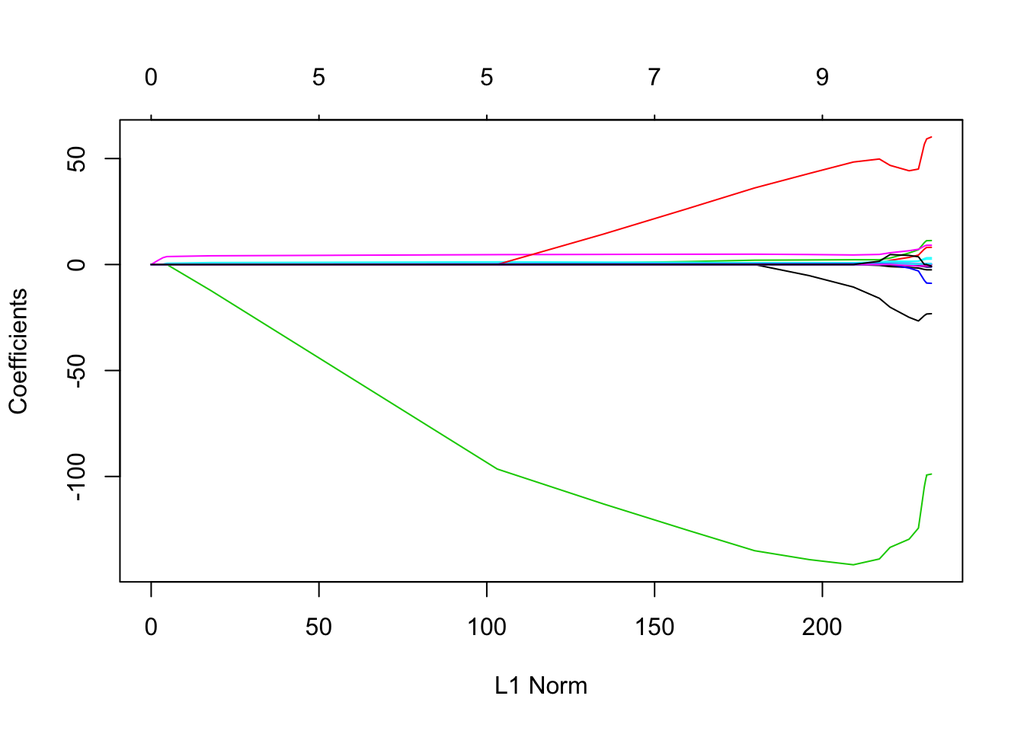

```r
lasso.model=glmnet(x[train,], y[train], alpha=1, lambda=grid)
plot(lasso.model)
```

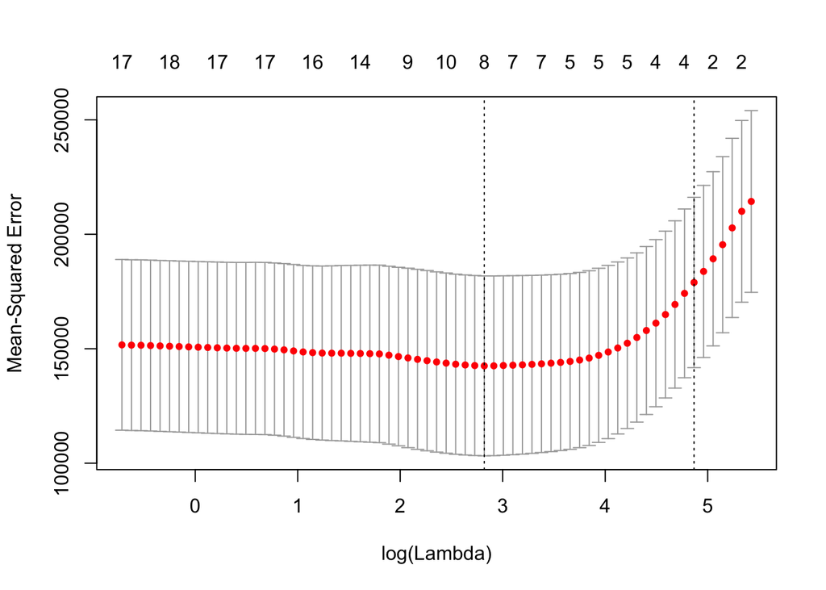

```r
set.seed(1)
cv.out = cv.glmnet(x[train,], y[train], alpha=1)
plot(cv.out)
```

```r
cv.out$lambda
```

```
##  [1] 227.0435609 206.8736367 188.4955530 171.7501276 156.4923197
##  [6] 142.5899733 129.9226731 118.3807009 107.8640857  98.2817376
## [11]  89.5506589  81.5952252  74.3465303  67.7417895  61.7237956
## [16]  56.2404237  51.2441795  46.6917878  42.5438181  38.7643425
## [21]  35.3206252  32.1828382  29.3238036  26.7187577  24.3451369
## [26]  22.1823820  20.2117603  18.4162033  16.7801585  15.2894555
## [31]  13.9311824  12.6935746  11.5659124  10.5384286   9.6022236
## [36]   8.7491886   7.9719348   7.2637301   6.6184403   6.0304763
## [41]   5.4947454   5.0066074   4.5618342   4.1565734   3.7873149
## [46]   3.4508603   3.1442953   2.8649648   2.6104492   2.3785441
## [51]   2.1672408   1.9747091   1.7992814   1.6394382   1.4937950
## [56]   1.3610904   1.2401749   1.1300012   1.0296150   0.9381468
## [61]   0.8548044   0.7788660   0.7096737   0.6466282   0.5891835
## [66]   0.5368421   0.4891505
```

```r
bestlam=cv.out$lambda.min
lasso.pred=predict(lasso.model, s=bestlam, newx=x[test,])
mean((lasso.pred-y.test)^2)
```

```
## [1] 100743.4
```

We can build lasso regression model using all the data, and then check the coefficients using lambda = bestlam.

```r
final_lasso = glmnet(x,y, alpha=1, lambda=grid)
lasso.coef=predict(final_lasso, type="coefficients", s=bestlam)
lasso.coef
```

```
## 20 x 1 sparse Matrix of class "dgCMatrix"
##                        1
## (Intercept)   18.5394844
## AtBat          .
## Hits           1.8735390
## HmRun          .
## Runs           .
## RBI            .
## Walks          2.2178444
## Years          .
## CAtBat         .
## CHits          .
## CHmRun         .
## CRuns          0.2071252
## CRBI           0.4130132
## CWalks         .
## LeagueN        3.2666677
## DivisionW   -103.4845458
## PutOuts        0.2204284
## Assists        .
## Errors         .
## NewLeagueN     .
```

We can see that the lasso model only includes 7 predictors + the intercept. All the other predictors have zero coefficients. Thus, lasso produces a slimmer and more easily interpretible model in this case.